# p8105_hw1_hc3653

# Probem 1

```r
library(moderndive)
data("early_january_weather")
```

### The variables

This dataset contains variables of origin, year, month, day, hour, temp, dewp, humid, wind_dir, wind_speed, wind_gust, precip, pressure, visib, time_hour.

### The size

This dataset has 358 rows and 15 columns.

### The mean temperature

The mean temperature is 39.58

### PLot and descriptions

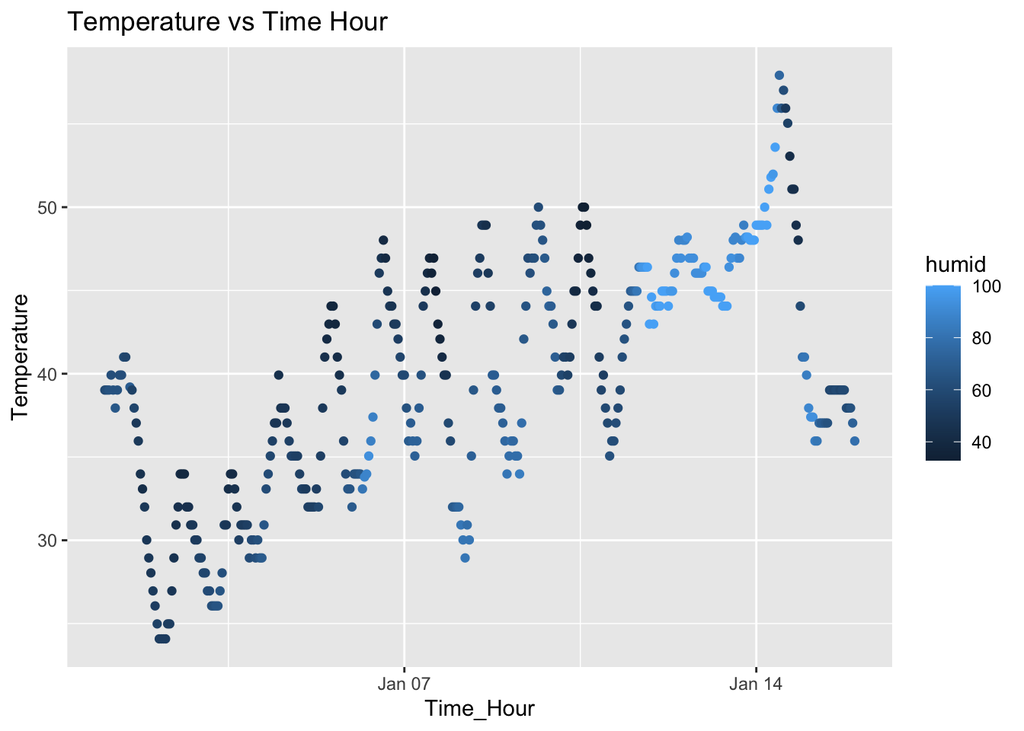

```r
library(ggplot2)

temp_time <-
  ggplot(early_january_weather, aes(x = time_hour, y = temp, color = humid)) +
       geom_point() +
       labs( title = "Temperature vs Time Hour",
             x = "Time_Hour",
             y = "Temperature")
print(temp_time)
```

From the plot, we can see that from early to mid-january, the temperature shows an increasing trend overall. However, the daily temperature fluctuates between day and night. When the temperature is higher, the humidity is also higher, therefore there is a positive relationship between temperature and humidity.

```r
ggsave(filename = "temp_vs_time.png",
       plot = temp_time )
```

# Problem 2

```r
library(tidyverse)
p2_df = tibble(
  norm_samp = rnorm(10),
  norm_samp_pos = norm_samp > 0,
  vec_char = c("apple","banana","peach","kiwi","mango",
               "strawberry","lemon","blueberry","grape","cherry"),
  vec_factor = factor(c("none", "a few", "none", "many", "many",
                        "a few", "none", "many", "a few", "a few"))
)
p2_df
```

```
## # A tibble: 10 × 4
##    norm_samp norm_samp_pos vec_char   vec_factor
##        <dbl> <lgl>         <chr>      <fct>
##  1    0.573  TRUE          apple      none
##  2   -0.168  FALSE         banana     a few
##  3   -0.264  FALSE         peach      none
##  4   -0.505  FALSE         kiwi       many
##  5   -0.772  FALSE         mango      many
##  6    0.0711 TRUE          strawberry a few
##  7   -0.425  FALSE         lemon      none
##  8   -0.0285 FALSE         blueberry  many
##  9    0.785  TRUE          grape      a few
## 10    0.631  TRUE          cherry     a few
```

```r
sapply(p2_df, mean)
```

```
##     norm_samp norm_samp_pos      vec_char    vec_factor
##   -0.01021465    0.40000000            NA            NA
```

As we can see from the result, it works for random sample and logical vector, but neither for character vector nor factor vector.

```r
mean(pull(p2_df, norm_samp))
```

```
## [1] -0.01021465
```

```r
mean(pull(p2_df, norm_samp_pos))
```

```
## [1] 0.4
```

```r
mean(pull(p2_df, vec_char))
```

```
## [1] NA
```

```r
mean(pull(p2_df, vec_factor))
```

```
## [1] NA
```

```r
as.numeric(p2_df$norm_samp_pos)
as.numeric(p2_df$vec_char)
as.numeric(p2_df$vec_factor)
```

For the logical vector, the function converts “TRUE” to 1 and “FALSE” to 0, since the logical values are internally stored as 0 and 1 in R. This explains why we can get the mean of logical vectors.

For the vector character, the result shows NA, becuase each character is unique and there are so many characters so that characters can’t be converted to numerical numbers. So even by using the pull function, we still can’t get the mean.

For the vector factor, they are stored as integers in R. For example, they can be converted to 1, 2 and etc according to levels assigned. But we need to apply the as.numeric function to accomplish this conversion, otherwise factors are not numerical numbers, thus we can’t have the mean of it.